# XAI on Time Series Forecasting

Author

Marco Zanotti

Published

November 20, 2023

[figure not shown]

# Setup

```r
install.packages("tidyverse")
install.packages("timetk")
install.packages("tidymodels")
install.packages("modeltime")
install.packages("modeltime.h2o")
install.packages("h2o")
install.packages("DALEX")
install.packages("DALEXtra")
install.packages("lime")
```

```r
library(tidyverse)
library(timetk)
library(tidymodels)
library(modeltime)
library(modeltime.h2o)
library(h2o)
library(DALEX)
library(DALEXtra)
library(lime)
```

# Data

The data used is an **hourly time series** from the **M4 competition**. The M4 competition is a large scale forecasting competition organized by Spyros Makridakis and his team. The competition was held in 2018 and the data is available on the [M4 competition website](https://www.m4.unic.ac.cy/the-dataset/). A sample of the data is available in the `data` folder of this repository.

## Import & Visualization

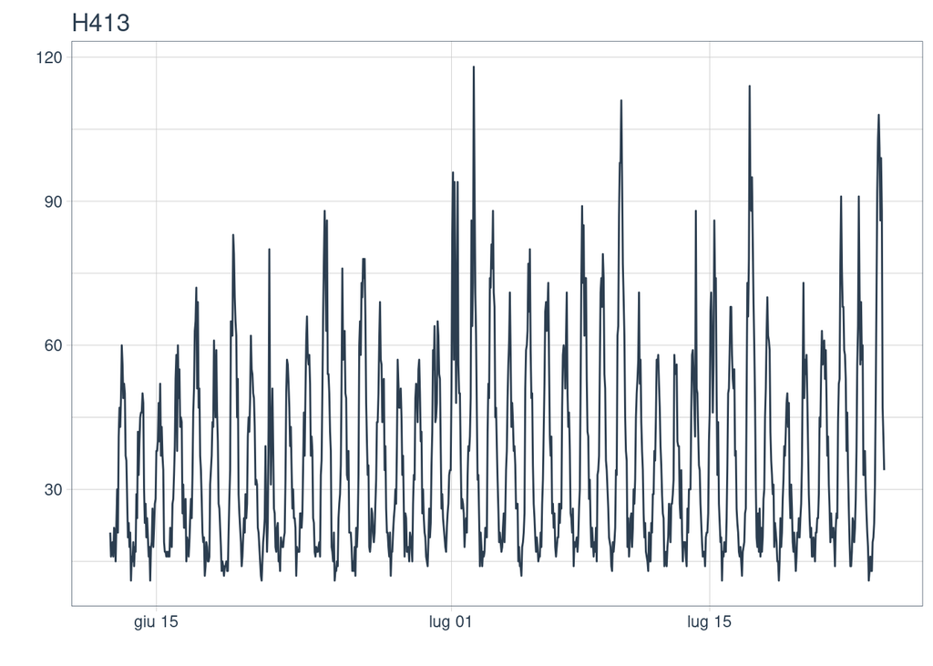

```r
m4 <- read_csv("../data/m4.csv")

freq <- "Hourly"
ts_id <- "H413"
m4_ts <- m4 |>
    filter(period == freq & id == ts_id) |>
    select(-id, -type, -period)

m4_ts |>
    plot_time_series(
        .date_var = date, .value = value,
        .smooth = FALSE, .title = ts_id, .interactive = FALSE
    )
```

## Feature Engineering

In order to be able to use data in a machine learning model, we need to create features that can be used as predictors. This step is extremely relevant in time series data, since we need to create **features that are able to capture the time dynamics of the data**. There exists a number of possible features that can be created; here I am using **lags, rolling features, calendar features and fourier series**, obtaining a total of **24 features**.

```r
horizon <- 48 # the forecast horizon, 2 days
lag_period <- 48 # 48h
rolling_periods <- c(12, 24) # 12h, 24h

m4_ts_prep <- m4_ts |>
    # standardization
    mutate(value = standardize_vec(value)) |>
    # add lags
    tk_augment_lags(value, .lags = lag_period) |>
    # add rolling features
    tk_augment_slidify(
        value_lag48, mean, .period = rolling_periods, .align = "center", .partial = TRUE
    ) |>
    rename_with(~ str_remove_all(., "(value_)|(lag48_)")) |>
    rename_with(~ str_remove_all(., "_")) |>
    # calendar features
    tk_augment_timeseries_signature(date) |>
    select(-matches("(diff)|(iso)|(xts)|(lbl)|(year)|(half)|(quarter)|(minute)|(second)|(hour12)|(qday)|(yday)")) |>
    mutate(
        index.num = standardize_vec(index.num),
        am.pm = as.factor(am.pm),
    ) |>
    # fourier series
    tk_augment_fourier(date, .periods = rolling_periods, .K = 2) |>
    rename_with(~ str_remove_all(., "date_")) |>
    # drop na
    drop_na()
glimpse(m4_ts_prep)
```

```
Rows: 949
Columns: 26
$ date      <dttm> 2017-06-14 23:00:00, 2017-06-15 00:00:00, 2017-06-15 01:00:…
$ value     <dbl> -0.42014242, 0.07019399, 0.07019399, 0.16826127, 0.56053041,…
$ lag48     <dbl> 0.21729492, 0.51149676, 0.31536220, 0.60956405, 1.14893410, …
$ roll12    <dbl> 0.06610786, 0.19277810, 0.33579288, 0.39299880, 0.41751562, …
$ roll24    <dbl> -0.1811034, -0.1770173, -0.1729311, -0.1647589, -0.1811034, …
$ index.num <dbl> -1.526815, -1.523381, -1.519946, -1.516511, -1.513076, -1.50…
$ month     <int> 6, 6, 6, 6, 6, 6, 6, 6, 6, 6, 6, 6, 6, 6, 6, 6, 6, 6, 6, 6, …
$ day       <int> 14, 15, 15, 15, 15, 15, 15, 15, 15, 15, 15, 15, 15, 15, 15, …
$ hour      <int> 23, 0, 1, 2, 3, 4, 5, 6, 7, 8, 9, 10, 11, 12, 13, 14, 15, 16…
$ am.pm     <fct> 2, 1, 1, 1, 1, 1, 1, 1, 1, 1, 1, 1, 1, 2, 2, 2, 2, 2, 2, 2, …
$ wday      <int> 4, 5, 5, 5, 5, 5, 5, 5, 5, 5, 5, 5, 5, 5, 5, 5, 5, 5, 5, 5, …
$ mday      <int> 14, 15, 15, 15, 15, 15, 15, 15, 15, 15, 15, 15, 15, 15, 15, …
$ mweek     <int> 3, 3, 3, 3, 3, 3, 3, 3, 3, 3, 3, 3, 3, 3, 3, 3, 3, 3, 3, 3, …
$ week      <int> 24, 24, 24, 24, 24, 24, 24, 24, 24, 24, 24, 24, 24, 24, 24, …
$ week2     <int> 0, 0, 0, 0, 0, 0, 0, 0, 0, 0, 0, 0, 0, 0, 0, 0, 0, 0, 0, 0, …
$ week3     <int> 0, 0, 0, 0, 0, 0, 0, 0, 0, 0, 0, 0, 0, 0, 0, 0, 0, 0, 0, 0, …
$ week4     <int> 0, 0, 0, 0, 0, 0, 0, 0, 0, 0, 0, 0, 0, 0, 0, 0, 0, 0, 0, 0, …
$ mday7     <int> 3, 3, 3, 3, 3, 3, 3, 3, 3, 3, 3, 3, 3, 3, 3, 3, 3, 3, 3, 3, …
$ sin12_K1  <dbl> -5.000000e-01, -3.617298e-11, 5.000000e-01, 8.660254e-01, 1.…
$ cos12_K1  <dbl> 8.660254e-01, 1.000000e+00, 8.660254e-01, 5.000000e-01, 9.63…
$ sin12_K2  <dbl> -8.660254e-01, -7.234595e-11, 8.660254e-01, 8.660254e-01, 1.…
$ cos12_K2  <dbl> 0.5, 1.0, 0.5, -0.5, -1.0, -0.5, 0.5, 1.0, 0.5, -0.5, -1.0, …
$ sin24_K1  <dbl> -2.588190e-01, -1.808649e-11, 2.588190e-01, 5.000000e-01, 7.…
$ cos24_K1  <dbl> 9.659258e-01, 1.000000e+00, 9.659258e-01, 8.660254e-01, 7.07…
$ sin24_K2  <dbl> -5.000000e-01, -3.617298e-11, 5.000000e-01, 8.660254e-01, 1.…
$ cos24_K2  <dbl> 8.660254e-01, 1.000000e+00, 8.660254e-01, 5.000000e-01, 9.63…
```

## Train & Test Sets

The data is then split considering a **test set of 2 days** to evaluate the models’ performances.

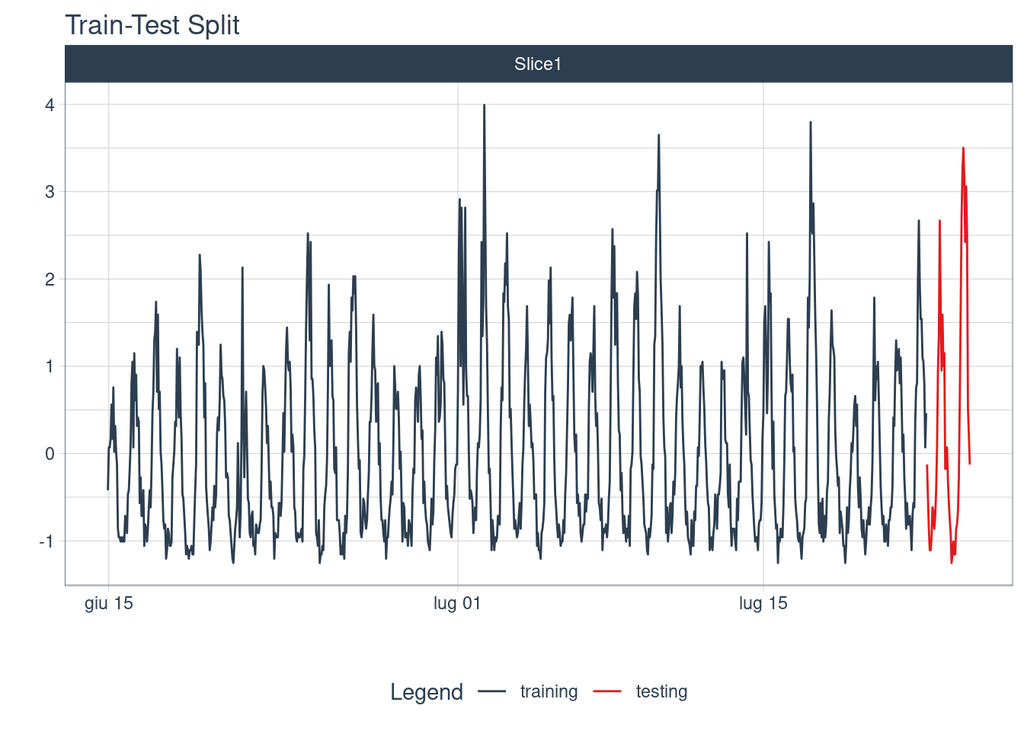

```r
splits <- m4_ts_prep |>
    time_series_split(assess = horizon, cumulative = TRUE)
splits |>
    tk_time_series_cv_plan() |>
    plot_time_series_cv_plan(
        date, value, .interactive = FALSE, .title = "Train-Test Split"
    )
```

# Modelling

ML models are estimated using an **AutoML approach**, which allows to efficiently estimate a large number of models and select the best one. The AutoML approach is performed using [**h2o**](https://h2o.ai/).

## H2O Setup

To use h2o, we need to initialize the Java Virtual Machine.

```r
Sys.setenv(JAVA_HOME = "/usr/lib/jvm/jdk-17/") # set java home path
h2o.init() # initialize h2o
h2o.no_progress() # disable progress bars
```

then, the data needs to be converted to h2o format

```r
train_h2o <- as.h2o(training(splits)) # convert train data to h2o
test_h2o <- as.h2o(testing(splits)) # convert test data to h2o
```

and we need to specify the target variable and the predictors.

```r
target <- "value"
x_vars <- setdiff(names(train_h2o), c(target, "date"))
```

## AutoML

**h2o** automatically estimates and tests **6 different ML algorithms**:

- DRF (This includes both the Distributed Random Forest (DRF) and Extremely Randomized Trees (XRT) models)
- GLM (Generalized Linear Model with regularization)
- XGBoost (XGBoost GBM)
- GBM (H2O GBM)
- DeepLearning (Fully-connected multi-layer artificial neural network)
- StackedEnsemble (Stacked Ensembles, includes an ensemble of all the base models and ensembles using subsets of the base models)

All this models are estimated using a 5-fold cross validation (since the data in not too large) and the best model is selected based on the RMSE metric.

```r
model_h2o_automl <- h2o.automl(
    y = target, x = x_vars,
    training_frame = train_h2o,
    max_runtime_secs = 120,
    max_runtime_secs_per_model = 30,
    max_models = 50,
    nfolds = 5,
    sort_metric = "rmse",
    verbosity = NULL,
    seed = 123
)
```

## Model Evaluation

The best model is extracted from the AutoML object and evaluated both on the train and the test sets.

```r
leader_board <- h2o.get_leaderboard(model_h2o_automl)
head(leader_board, 10)[, 1:2]
```

```
                                          model_id      rmse
1                   GBM_2_AutoML_1_20231222_114747 0.3357411
2                   GBM_4_AutoML_1_20231222_114747 0.3389956
3  XGBoost_grid_1_AutoML_1_20231222_114747_model_2 0.3418421
4                   GBM_3_AutoML_1_20231222_114747 0.3441333
5                   GBM_5_AutoML_1_20231222_114747 0.3497250
6  XGBoost_grid_1_AutoML_1_20231222_114747_model_1 0.3575881
7               XGBoost_3_AutoML_1_20231222_114747 0.3650229
8               XGBoost_1_AutoML_1_20231222_114747 0.3672501
9               XGBoost_2_AutoML_1_20231222_114747 0.3698911
10                  DRF_1_AutoML_1_20231222_114747 0.3753290
```

```r
tail(leader_board, 10)[, 1:2]
```

```
                                          model_id      rmse
1  XGBoost_grid_1_AutoML_1_20231222_114747_model_1 0.3575881
2               XGBoost_3_AutoML_1_20231222_114747 0.3650229
3               XGBoost_1_AutoML_1_20231222_114747 0.3672501
4               XGBoost_2_AutoML_1_20231222_114747 0.3698911
5                   DRF_1_AutoML_1_20231222_114747 0.3753290
6  XGBoost_grid_1_AutoML_1_20231222_114747_model_3 0.3765141
7                   XRT_1_AutoML_1_20231222_114747 0.3795674
8                   GBM_1_AutoML_1_20231222_114747 0.3910087
9                   GLM_1_AutoML_1_20231222_114747 0.4575652
10         DeepLearning_1_AutoML_1_20231222_114747 0.4979162
```

```r
h2o_best <- h2o.get_best_model(model_h2o_automl)
h2o_best
```

```
Model Details:
==============

H2ORegressionModel: gbm
Model ID:  GBM_2_AutoML_1_20231222_114747
Model Summary:
  number_of_trees number_of_internal_trees model_size_in_bytes min_depth
1              53                       53               25669         7
  max_depth mean_depth min_leaves max_leaves mean_leaves
1         7    7.00000         14         51    33.88679


H2ORegressionMetrics: gbm
** Reported on training data. **

MSE:  0.03987579
RMSE:  0.1996892
MAE:  0.1444855
RMSLE:  NaN
Mean Residual Deviance :  0.03987579



H2ORegressionMetrics: gbm
** Reported on cross-validation data. **
** 5-fold cross-validation on training data (Metrics computed for combined holdout predictions) **

MSE:  0.1127221
RMSE:  0.3357411
MAE:  0.237404
RMSLE:  NaN
Mean Residual Deviance :  0.1127221


Cross-Validation Metrics Summary:
                           mean       sd cv_1_valid cv_2_valid cv_3_valid
mae                    0.237983 0.008009   0.239397   0.226926   0.239965
mean_residual_deviance 0.113160 0.023444   0.102133   0.099002   0.097910
mse                    0.113160 0.023444   0.102133   0.099002   0.097910
r2                     0.883662 0.019052   0.889773   0.893748   0.900770
residual_deviance      0.113160 0.023444   0.102133   0.099002   0.097910
rmse                   0.335083 0.033153   0.319582   0.314646   0.312906
rmsle                        NA 0.000000         NA         NA         NA
                       cv_4_valid cv_5_valid
mae                      0.248852   0.234777
mean_residual_deviance   0.153704   0.113052
mse                      0.153704   0.113052
r2                       0.851754   0.882265
residual_deviance        0.153704   0.113052
rmse                     0.392051   0.336231
rmsle                          NA         NA
```

The performance of the best model on the train set is given by

```r
h2o.performance(h2o_best, train_h2o)
```

```
H2ORegressionMetrics: gbm

MSE:  0.0398758
RMSE:  0.1996893
MAE:  0.1444855
RMSLE:  NaN
Mean Residual Deviance :  0.0398758
```

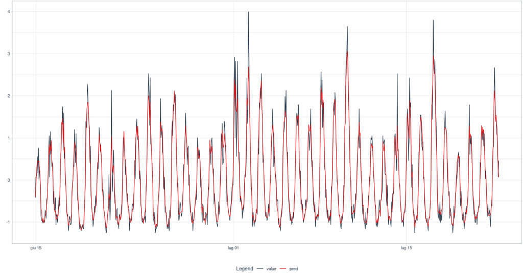

while the performance on the test set is

```r
h2o.performance(h2o_best, test_h2o)
```

```
H2ORegressionMetrics: gbm

MSE:  0.3487837
RMSE:  0.5905791
MAE:  0.4110881
RMSLE:  NaN
Mean Residual Deviance :  0.3487837
```

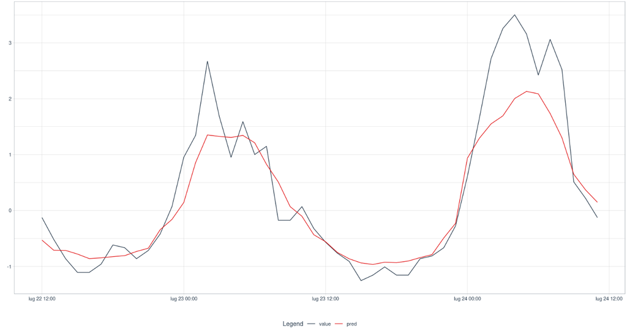

# XAI

In the context of time series forecasting, being able to understand the model’s predictions is of paramount importance for 3 main reasons:

1. **Trust**: to be able to trust the model’s predictions, especially when it is used to make important future decisions.
2. **Improvement**: to be able to understand the model’s weaknesses to improve it.
3. **Combine**: usually model’s predictions are combined with human judgement, so understanding what causes such predictions is crucial for business experts to adjust their forecasts.

Given the fact that AutoML models are black-boxes, we would like to better understand why the model is predicting what it is predicting. To do so, it is possible to use the **DALEX** package, from [Dr. Why AI](https://dalex.drwhy.ai/), which allows to easily adopt several model explainability techniques, from global to local ones, to obtain an in-depth analysis of the model’s results.

## Explainer

Using **DALEX** is almost straightforward since it is model agnostic and it interfaces with most of ML and DL frameworks (scikit-learn, keras, tensorflow, h2o, tidymodels, mlr) through the **DALEXtra** extension.  
First, it is necessary to create a **DALEX explainer**

```r
explainer_h2o_automl <- explain_h2o(
    model = h2o_best,
    data = select(testing(splits), -date, -value),
    y = testing(splits)$value,
    label = "h2o automl",
    type = "regression",
    colorize = FALSE
)
```

## Global Explanations

Then, it is possible to use the explainer to obtain dataset-level or **global explanations** of the model. This analysis helps to understand how the model predictions perform overall, for an entire set of observations. Hence, assuming that the observations form a representative sample from a general population, global explainers can provide information about the quality of predictions for the population.

### Feature Importance

First, we can inspect the **feature importance** of the model, that is the relevance of each feature in the model’s predictions.

```r
fe_h2o_automl <- model_parts(explainer_h2o_automl)
plot(fe_h2o_automl)
```

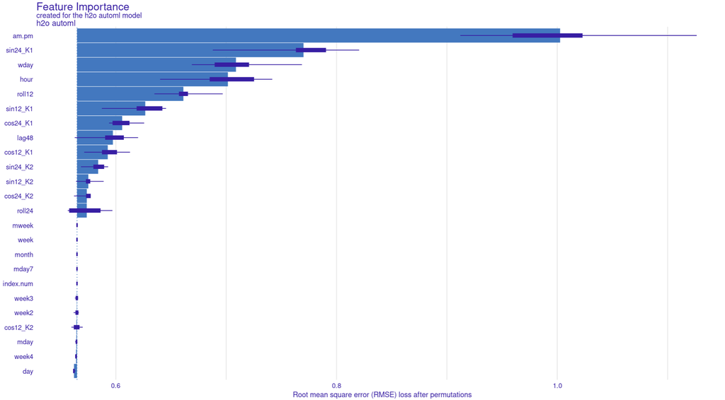

### Partial Dependence

Then, we can inspect the **partial dependence** of the model, that shows how does the expected value of model prediction behave as a function of a selected explanatory variable. Hence, it is a simple way to summarize the effect of a particular explanatory variable on the dependent variable. Moreover, this tool is very useful to understand the model performance at boundaries (since models may have strange behaviours at the boundaries of the possible range of a variable).

```r
pdp_h2o_automl <- model_profile(
    explainer_h2o_automl,
    variable = c("hour", "wday"),
    type = "partial"
)
plot(pdp_h2o_automl)
```

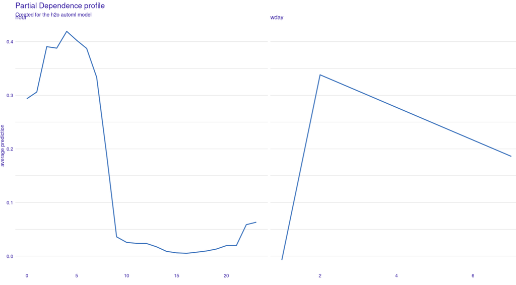

### Global Results

As shown by the **Feature Importance** plot, the most important features are those related to **daily seasonality**, while weekly and monthly seasonality seem to be irrelevant. The **day of the week** is also of great importance.

The PD for the **hour** and the **day of the week** variables reveals a clear intra-day pattern, with higher predictions during the night, and a downward trending effect within the week (where wday = 1 means Sunday).

## Local Explanations

It is possible to use the explainer to obtain also instance-level or **local explanations**, helping understand how a model yields a prediction for a particular single observation. Indeed, in this case it is necessary to specify an observation to be explained. In the context of time series forecasting, one may explore test observations to inspect how future values are produced by the model.  
Here, in particular, I focused on test observations where the model is failing, that is

- in the **afternoon** of the **23rd of July 2017** and
- in the **first hours** of the **23th of July 2017** and **24th of July 2017**,

possibly suggesting that the model is not completely capturing intra-day dynamics.  
(The results for the first hours of the 23 and 24 of July are almost the same)

```r
new_value_2h <- testing(splits) |> filter(date == ymd_hms("2017-07-23 02:00:00"))
new_value_4h <- testing(splits) |> filter(date == ymd_hms("2017-07-24 04:00:00"))
new_value_15h <- testing(splits) |> filter(date == ymd_hms("2017-07-23 15:00:00"))
```

### Break Down

In the context of local explainability, one of the main questions that one may want to answer is “which variables contribute to this result the most?”, and several different approaches have been proposed to address this issue. The **break-down** method shows how the contributions attributed to individual explanatory variables change the mean model’s prediction to yield the actual prediction for a particular single instance.

```r
bd_h2o_automl <- predict_parts(
    explainer_h2o_automl,
    new_observation = new_value_xh,
    type = "break_down"
)
plot(bd_h2o_automl)
```

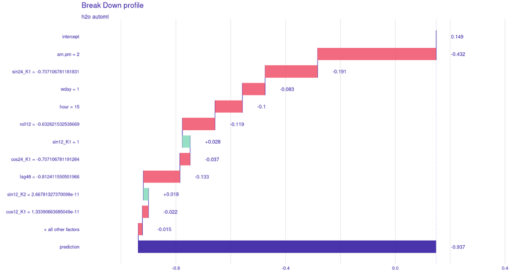

Observation: 2017-07-23 15:00:00

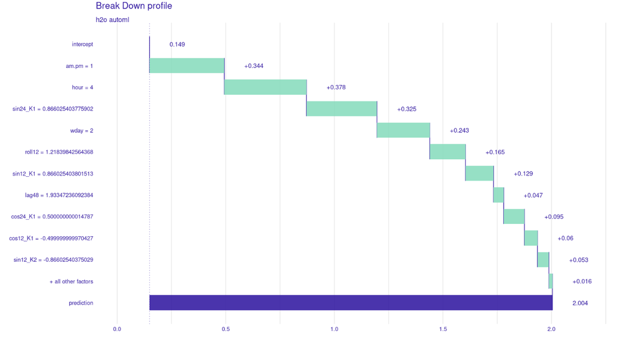

Observation: 2017-07-24 04:00:00

### SHAP

**SHapley Additive exPlanations** (SHAP) is another method used to understand what variables contributed the most to a particular prediction and it is based on Shapley values from game theory.

```r
shap_h2o_automl <- predict_parts(
    explainer_h2o_automl,
    new_observation = new_value_xh,
    type = "shap"
)
plot(shap_h2o_automl)
```

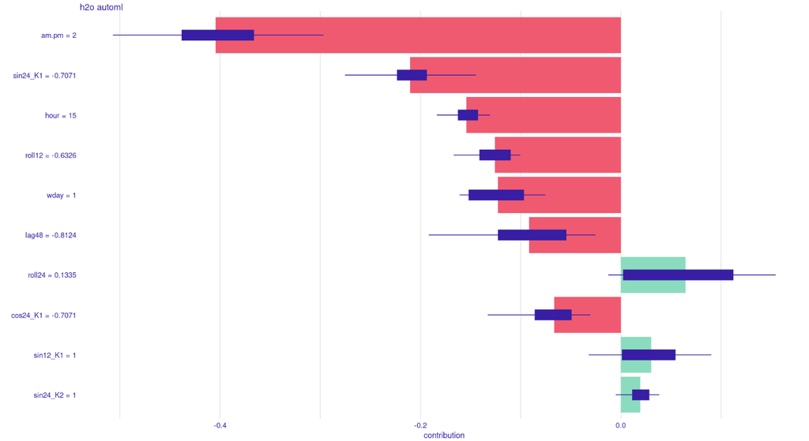

Observation: 2017-07-23 15:00:00

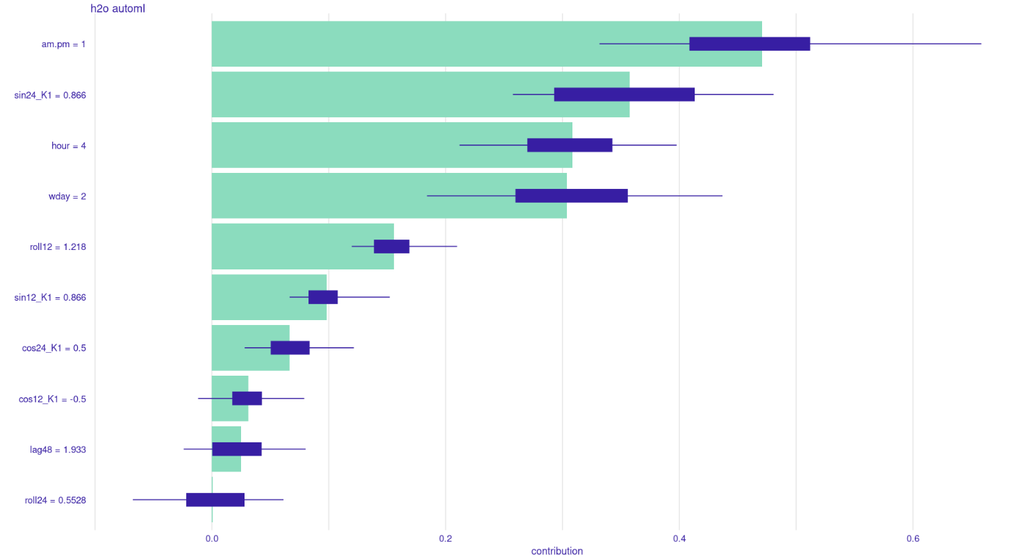

Observation: 2017-07-24 04:00:00

### Lime

Break-down (BD) plots and Shapley values are most suitable for models with a small or moderate number of explanatory variables. None of those approaches is well-suited for models with a very large number of explanatory variables, because they usually determine non-zero attributions for all variables in the model. However, when the number of explanatory variables is huge, **sparse explanations** with a small number of variables may offer a useful alternative. The most popular of such sparse explainers is the **Local Interpretable Model-agnostic Explanations** (LIME) method. The key idea behind it is to locally approximate a black-box model by a simpler and easy to interpret linear regression model.

```r
model_type.dalex_explainer <- DALEXtra::model_type.dalex_explainer
predict_model.dalex_explainer <- DALEXtra::predict_model.dalex_explainer

lime_h2o_automl <- predict_surrogate(
    explainer = explainer_h2o_automl,
    new_observation = new_value_xh,
    n_features = 10,
    n_permutations = 1000,
    type = "lime"
)
plot(lime_h2o_automl)
```

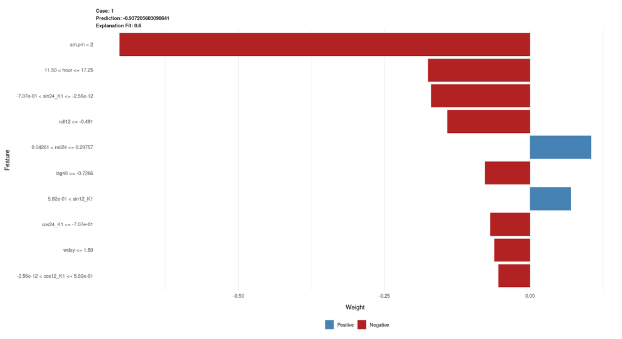

Observation: 2017-07-23 15:00:00

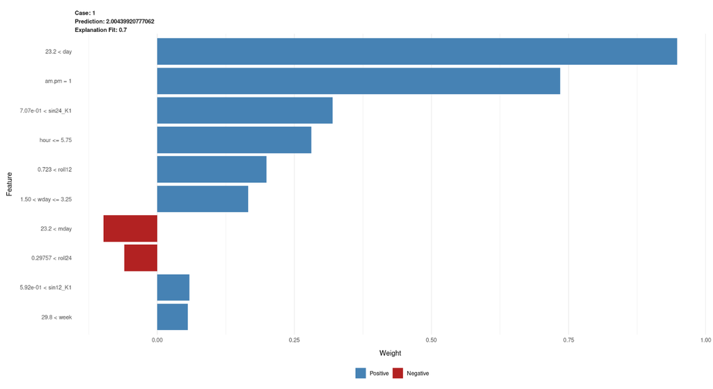

Observation: 2017-07-24 04:00:00

However, the LIME method is not well suited for time series data, because there are several important limitations in case of tabular data. In particular, there have been various proposals for finding interpretable representations for continuous and categorical explanatory variables but the issue has not been solved yet.

### Ceteris Paribus

The previous local explainability methods quantified the importance of explanatory variables in the context of a single-instance prediction and their application yields a decomposition of the prediction into components that can be attributed to particular variables.  
**Ceteris Paribus**, instead, is a method that evaluates the effect of a selected explanatory variable in terms of changes of a model’s prediction induced by changes in the variable’s values. The method is based on the ceteris paribus principle, that is it examines the influence of an explanatory variable by assuming that the values of all other variables do not change (i.e. the dependence of the conditional expectation of the dependent variable on the values of the particular explanatory variable).

```r
cetp_h2o_automl <- predict_profile(
    explainer = explainer_h2o_automl,
    new_observation = new_value_xh,
    type = "ceteris_paribus",
    variables = c("hour", "wday")
)
plot(cetp_h2o_automl, variables = c("hour", "wday"))
```

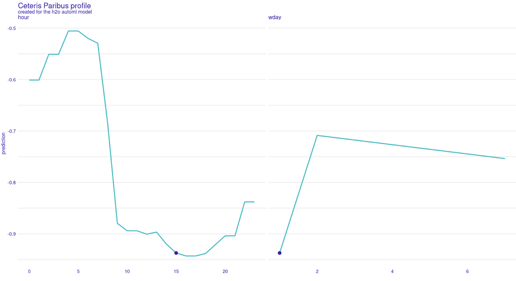

Observation: 2017-07-23 15:00:00

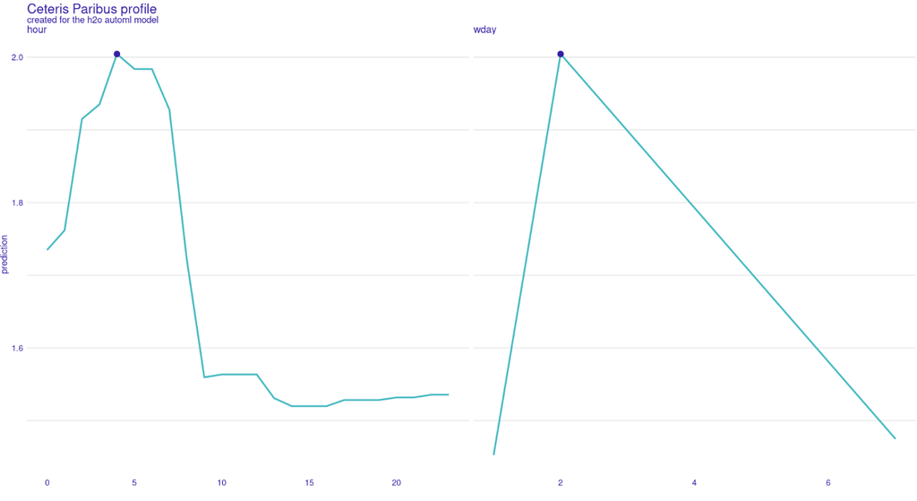

Observation: 2017-07-24 04:00:00

### Stability Analysis

It may happen that, despite the fact that the predictive performance of a model is satisfactory overall, the model’s predictions for some observations are drastically worse. For example, a model developed to forecast product demand may perform well during spring and may not in autumn. In this case, it is worthwhile to check how does the model behave locally for observations similar to the instance of interest and the **Local-stability** analysis allows to assess the (local) stability of predictions around the observation of interest. It is based first on the identification of a set of neighbors for the observation of interest and then on the comparison of ceteris paribus profiles for selected explanatory variables.

```r
preddiag_h2o_automl <- predict_diagnostics(
    explainer = explainer_h2o_automl,
    new_observation = new_value_xh,
    variables = c("hour", "wday"),
    neighbors = 50,
  distance = gower::gower_dist
)
plot(preddiag_h2o_automl, variables = c("hour", "wday"))
```

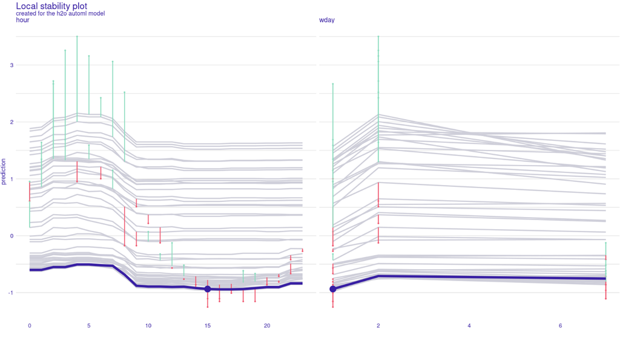

Observation: 2017-07-23 15:00:00

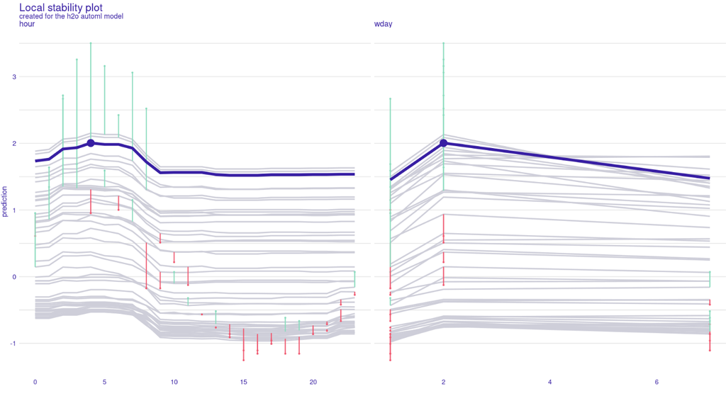

Observation: 2017-07-24 04:00:00

### Local Results

Finally, the **Stability Analysis** shows that the profiles are not relatively close to each other, suggesting some “instability” of predictions.  
Moreover, there are very positive residuals in the morning, suggesting that the model is on average underestimating the demand in the morning, while there are more negative residuals in the afternoon and evening, implying that the model is on average overestimating the demand in that part of the day. This information is extremely useful for the judgemental forecasting adjustment business experts may adopt to improve business results.

Finally, remember to shut down the h2o cluster.

```r
h2o.shutdown(prompt = FALSE)
```